# Linear Regression: Public Transit Ridership, Gender, & Income

This report assesses the potential linear relationship between the choice of taking public transit based on the predictors of gender and income/poverty level. We are using 5 year census data for 2018 at both the individual level and aggregated across the Bay Area.

Furthermore, in the webinar series “Ideas + Action 2020: Public Space” by SPUR, a panel regarding Safe Streets raised the question of safety in public spaces and transit in regards to gender, among other identities. Female and non-binary people may feel less safe due to the possibility of assault. The International Transportation Forum launched an [entire report](https://www.itf-oecd.org/sites/default/files/docs/womens-safety-security_0.pdf) on this topic, citing that transportation systems must be redesigned with women in mind.

These findings prompt a multiple regression analysis of the association between income, gender, and whether or not someone takes public transportation. In our case, we focus on low income households, either through their income-poverty ratio for an individual (analysis 1) or whether someone makes under 75K (analysis 2). It should be noted that while ACS 5-year estimates only include male and female sex, a more thorough and equitable analysis would include multiple gender identities as well.

```r
library(tidyverse)
library(sf)
library(tigris)
library(leaflet)
library(censusapi)
library(tidycensus)

Sys.setenv(CENSUS_KEY="c8aa67e4086b4b5ce3a8717f59faa9a28f611dab")

acs_vars_2018_5yr <-
listCensusMetadata(
    name = "2018/acs/acs5",
    type = "variables"
)

saveRDS(acs_vars_2018_5yr,"acs_vars_2018_5yr.rds")
```

## Individual & Household Analysis

We use person-level PUMS data to understanding the relationship. We use SEX (whether someone is male or female), JWTR (mode of transportation used to work), and POVPIP (income-poverty ratio). JWTR lists multiple forms of transportation, and we consider the following as “public transit”: bus/trolley bus, streetcar/trolley car, subway, railroad, ferryboat, biking, and walking. We do not consider taxicab in this analysis to stay consistent with the non-PUMS analysis below this example, which excludes taxicabs. POVPIP is used as a proxy for individual income in this case, since it includes a more granular estimate of income at the individual level than other PUMS data, which focuses on much larger income buckets or is at the household level. As POVPIP increases, the less in proximity someone is in poverty.

```r
# ca_pums <- get_pums(
#   variables = c(
#     "PUMA",
#     "JWTR",
#      "SEX",
#      "NP",
#      "POVPIP"
#    ),
#    state = "CA",
#    survey = "acs5",
#    recode = T
#  )
#
#  saveRDS(ca_pums,"ca_pums.rds")
```

```r
ca_pums <- readRDS("ca_pums.rds")

ca_pumas <-
   pumas("CA", cb = T, progress_bar = F)

bay_county_names <-
  c(
    "Alameda",
    "Contra Costa",
    "Marin",
    "Napa",
    "San Francisco",
    "San Mateo",
    "Santa Clara",
    "Solano",
    "Sonoma"
  )

bay_counties <-
  counties("CA", cb = T, progress_bar = F) %>%
  filter(NAME %in% bay_county_names)

bay_pumas <-
  ca_pumas %>%
  st_centroid() %>%
  .[bay_counties, ] %>%
  st_set_geometry(NULL) %>%
  left_join(ca_pumas %>% dplyr::select(GEOID10)) %>%
  st_as_sf()

bay_pums <-
  ca_pums %>%
  filter(PUMA %in% bay_pumas$PUMACE10)
```

```r
bay_pums_variables <-
  bay_pums %>%
    mutate(
      transit =
      ifelse(
        JWTR == c(2, 3, 4, 5, 6, 9, 10), #walking, biking, and use of: bus, streetcar, subway, railroad, ferryboat
        1,
        0
      ),
      gender =
      ifelse(
        SEX == 2,
        1,
        0
      )
    )
```

```r
model_pums <- lm(transit ~  gender  + POVPIP, bay_pums_variables, weights = PWGTP)
summary(model_pums)
```

```
##
## Call:
## lm(formula = transit ~ gender + POVPIP, data = bay_pums_variables,
##     weights = PWGTP)
##
## Weighted Residuals:
##     Min      1Q  Median      3Q     Max
## -0.0494 -0.0122 -0.0100 -0.0085 11.8465
##
## Coefficients:
##               Estimate Std. Error t value Pr(>|t|)
## (Intercept)  3.169e-03  2.125e-04  14.914  < 2e-16 ***
## gender      -1.398e-04  1.632e-04  -0.857 0.391613
## POVPIP      -1.646e-06  4.890e-07  -3.367 0.000761 ***
## ---
## Signif. codes:  0 '***' 0.001 '**' 0.01 '*' 0.05 '.' 0.1 ' ' 1
##
## Residual standard error: 0.2259 on 376054 degrees of freedom
## Multiple R-squared:  3.168e-05,  Adjusted R-squared:  2.636e-05
## F-statistic: 5.957 on 2 and 376054 DF,  p-value: 0.002589
```

## Tract Analysis

For this version, we are focused on workers in the Bay Area, using gender and income as indicators and the choice of walking or public transportation as the response variable.

```r
acs_vars_2018_5yr  <-
  readRDS("acs_vars_2018_5yr.rds")

#B08119: public transit by income
bay_tract_transit_income <-
  getCensus(
    name = "acs/acs5",
    vintage = 2018,
    region = "tract:*",
    regionin = "state:06+county:001,013,041,055,075,081,085,095,097",
    vars = c(
      "B08119_001E", #total
      "B08119_037E", #total - walked
      "B08119_028E", #total - public transit
      #for each income level below 75,000
      "B08119_002E",
      "B08119_003E",
      "B08119_004E",
      "B08119_005E",
      "B08119_006E",
      "B08119_007E",
      "B08119_008E"
    )
  ) %>%
  mutate(
    tract = paste0(state, county, tract),
    perc_transit_walk = (B08119_037E + B08119_028E)/B08119_001E,
    perc_under75k = (B08119_002E + B08119_003E + B08119_004E + B08119_005E + B08119_006E + B08119_007E + B08119_008E) / B08119_001E
  ) %>%
  filter(
    !is.na(perc_transit_walk),
    !is.na(perc_under75k)
  )
```

```r
bay_tract_gender <-
  getCensus(
    name = "acs/acs5",
    vintage = 2018,
    region = "tract:*",
    regionin = "state:06+county:001,013,041,055,075,081,085,095,097",
    vars = c(
      "B08012_001E", #female workers (based on commute time)
      "B08012_027E" #total workers (based on commute time)
    )
  ) %>%
  mutate(
    tract = paste0(state, county, tract),
    perc_women = B08012_027E/B08012_001E
  ) %>%
  filter(
    !is.na(perc_women)
  )
```

```r
gender_income_transit <-
  bay_tract_transit_income %>%
    left_join(bay_tract_gender)
```

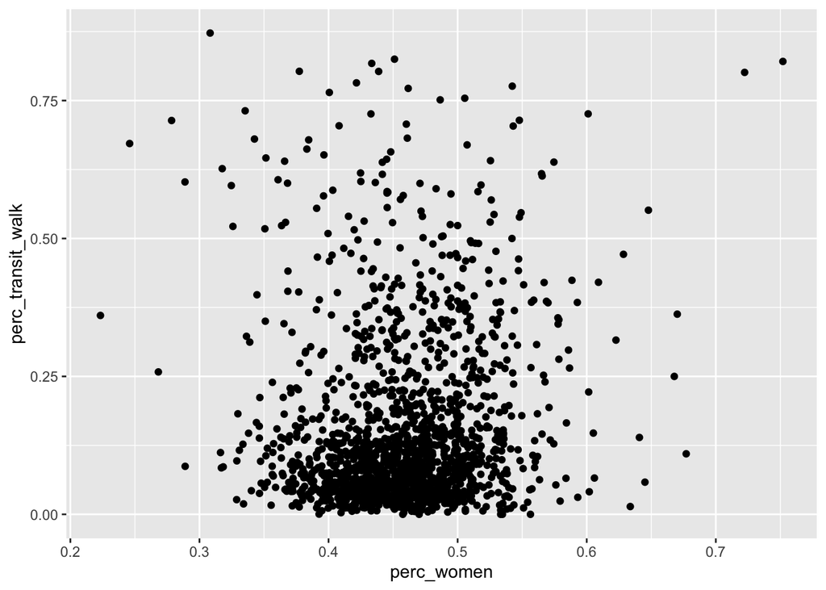

```r
ggplot() +
  geom_point(
    data = gender_income_transit,
    aes(
      x = perc_women,
      y = perc_transit_walk
    )
  )
```

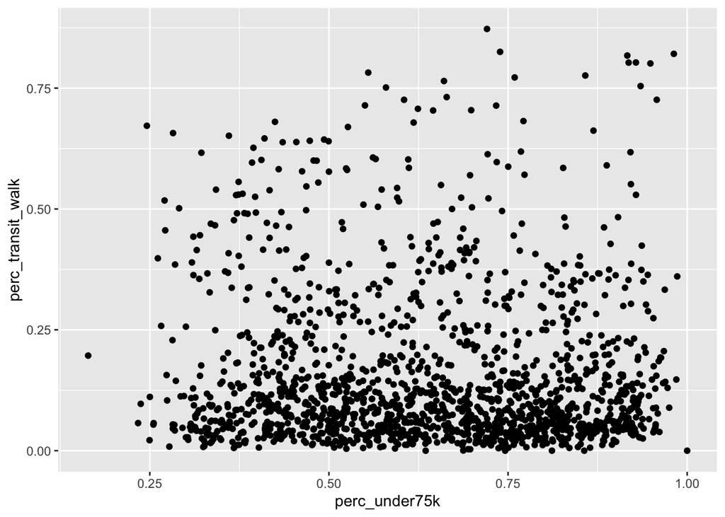

```r
ggplot() +
  geom_point(
    data = gender_income_transit,
    aes(
      x = perc_under75k,
      y = perc_transit_walk
    )
  )
```

The following scatter plot briefly shows the relationship between income (under 75K) or gender (% women) on the x axis and their corresponding y value of % of transit users and walkers per tract value. The distribution of low ridership across the Bay Area may present an issue for our results.

```r
model_total <- lm(perc_transit_walk ~ perc_under75k + perc_women, gender_income_transit)

summary(model_total)
```

```
##
## Call:
## lm(formula = perc_transit_walk ~ perc_under75k + perc_women,
##     data = gender_income_transit)
##
## Residuals:
##      Min       1Q   Median       3Q      Max
## -0.18477 -0.10521 -0.05722  0.04542  0.75976
##
## Coefficients:
##               Estimate Std. Error t value Pr(>|t|)
## (Intercept)    0.06801    0.03527   1.928 0.054005 .
## perc_under75k -0.05291    0.02202  -2.402 0.016413 *
## perc_women     0.26844    0.07513   3.573 0.000364 ***
## ---
## Signif. codes:  0 '***' 0.001 '**' 0.01 '*' 0.05 '.' 0.1 ' ' 1
##
## Residual standard error: 0.1578 on 1574 degrees of freedom
## Multiple R-squared:  0.01018,    Adjusted R-squared:  0.00892
## F-statistic: 8.092 on 2 and 1574 DF,  p-value: 0.0003189
```

We also see that that both values were statistically significant, with % under 75K being significant at the 95% level. However, in this analysis, gender was extremely significant. The positive coefficient suggests that for nearly any sample, gender had a positive correlation with the tract, while income under 75K had a negative correlation. Both findings are contrary to much of the evidence presented that gender can deter use of transit while being under an income threshold may increase utilization; the point on gender differs as well from the individual analysis. However, both coefficients are < 1, implying that neither has a particularly strong effect on choice of public transit.

Overall, this particular analysis does not yield a causal relationship, and COVID-19 may further disrupt transportation choices that this data does not capture. The scale of this analysis was also very large, given the attempt to subject the entire Bay Area to analysis, even if transportation systems are only strong in some of the counties. However, understanding barriers to a safe, comfortable public transit experience across demographic is key to designing more equitable systems and will require more qualitative research on local systems.